# Multiplex Canada Predictive Projection

## Set-up

```r
knitr::opts_knit$set(root.dir = "~/R files/multiplex canada")
# to ensure that the project is at the root directory
knitr::opts_chunk$set(echo = TRUE, warning = F, fig.width=14, fig.height=18, message = F)
```

### Packages

```r
library(projpred) # main package
library(brms) # for bayesian statistics
library(tidyverse) # for tidy format
library(bayesplot) # to plot bayesian models
theme_set(bayesplot::theme_default(base_family = "sans"))
require(mice)
# require(loo)
```

### Load imputed data and functions

```r
mice1l<- read.csv("3_intermediate/imputed/imputed_data_long_no_prom_1l.csv")
mice_obj<- as.mids(mice1l)  # load the imputed data
source("2_scripts/00_functions.R") # functions
```

## Imputed data

For now I am using the 1-level predictive selection for binary variables (like Cindy).

In future steps, I will compare the results to those from other imputation models.

### Select training vs testing dataset

```r
pooled.imp<- complete(mice_obj) # pool imputed data


unique_ids_imp<-pooled.imp$p_id

# Stratified sampling using dplyr
training_set_imp <- pooled.imp %>%
  group_by(site) %>%
  sample_frac(0.75, replace = FALSE) %>%
  ungroup() %>%
  arrange(p_id)

sampled_ids_imp <- training_set_imp$p_id

# testing set from the non-selected variables
testing_set_imp <- pooled.imp %>%
  filter(!p_id %in% sampled_ids_imp)


## check
length(unique_ids_imp) == length(unique(append(training_set_imp$p_id, testing_set_imp$p_id)))
```

```
[1] TRUE
```

### Fitting a reference model

First we create a column with outcome of interest (STBBI status)

```r
training_set_imp <- training_set_imp %>%
  mutate(stbbi.pos = case_when(
    hcv.pos %in% 1~1,
    hiv.pos %in% 1~1,
    syphilis.pos %in% 1 ~1,
    T ~0),
    TypePastSTD = case_when(
      TypePastSTD %in% "None" ~ as.factor(TypePastSTD),
      TypePastSTD %in% "6-Other" ~ "Not specified",
      T ~ "Specified"
    )) %>%
  select(- c(new.hcv, new.syphilis, new.hiv, p_id, Date.Recruited, syphilis.pos, hcv.pos, hiv.pos)) %>%
   mutate_if(is.character, as.factor)


summary(training_set_imp)
```

```
                   SexualActivity   CondomUse     SexualPartners
 0-No or no wish to answer: 82    0-Never: 80   0 to 5   :252
 1-Yes                    :218    1-Ever :220   6 or more: 48




                PastSTD           TypePastSTD                   PastInjectDrugs
 0-No or do not know:169   None         :170   0-No or no wish to answer:193
 1-Yes              :131   Not specified: 16   1-Yes                    :107
                           Specified    :114



 ShareNeedles               Alcohol                           PastHIVTest
 0-No :234    0-No              :162   0-No                         : 42
 1-Yes: 66    1-5 times per week:138   1-Yes; less than 6 months ago:104
                                       2-Yes; 6 months to 1 year ago: 35
                                       3-Yes; more than 1 year ago  :119


                        PastHCVTest                       PastSyphilisTest
 0-No                         : 31   0-No                         :  2
 1-Yes; less than 6 months ago:104   1-Yes; less than 6 months ago: 95
 2-Yes; 6 months to 1 year ago: 36   2-Yes; 6 months to 1 year ago: 34
 3-Yes; more than 1 year ago  :129   3-Yes; more than 1 year ago  :169


              PastSyphilis           Age                Gender
 0-No or do not know:269   18 to 34    :130   1-Male       :213
 1-Yes              : 31   35 and above:170   2-Female     : 70
                                              3-Transgender:  5
                                              5-No response: 12


                                                                    Descent
 Mediterranean European, African, Latin American, Caribbean and/or Asian: 83
 Non-Mediterranean European/North American                              :217




                EducationStatus                  WorkStatus
 4-Post-graduate degree : 91    Currently employed    :147
 No post-graduate degree:209    Not currently employed:153




          MonthlyIncomeStatus CurrentPartner      site        stbbi.pos
 $2000 CAD and above:104      0-No :185      Min.   :0.00   Min.   :0.0000
 1-<$2;000 CAD      :196      1-Yes:115      1st Qu.:0.00   1st Qu.:0.0000
                                             Median :0.00   Median :0.0000
                                             Mean   :0.41   Mean   :0.1767
                                             3rd Qu.:1.00   3rd Qu.:0.0000
                                             Max.   :1.00   Max.   :1.0000
```

**Note:** There are 53 stbbi positive individuals in the training sample

Same for testing

```r
testing_set_imp <- testing_set_imp %>%
mutate(stbbi.pos = case_when(
    hcv.pos %in% 1~1,
    hiv.pos %in% 1~1,
    syphilis.pos %in% 1 ~1,
    T ~0),
    TypePastSTD = case_when(
      TypePastSTD %in% "None" ~ as.factor(TypePastSTD),
      TypePastSTD %in% "6-Other" ~ "Not specified",
      T ~ "Specified"
    )) %>%
  select(- c(new.hcv, new.syphilis, new.hiv, p_id, Date.Recruited, syphilis.pos, hcv.pos, hiv.pos)) %>%
   mutate_if(is.character, as.factor)

## check
ncol(testing_set_imp) == ncol(training_set_imp)
```

```
[1] TRUE
```

```r
summary(testing_set_imp)
```

```
                   SexualActivity   CondomUse    SexualPartners
 0-No or no wish to answer:25     0-Never:26   0 to 5   :83
 1-Yes                    :75     1-Ever :74   6 or more:17




                PastSTD          TypePastSTD                  PastInjectDrugs
 0-No or do not know:53   None         :53   0-No or no wish to answer:65
 1-Yes              :47   Not specified: 9   1-Yes                    :35
                          Specified    :38



 ShareNeedles               Alcohol                          PastHIVTest
 0-No :78     0-No              :51   0-No                         :15
 1-Yes:22     1-5 times per week:49   1-Yes; less than 6 months ago:37
                                      2-Yes; 6 months to 1 year ago:12
                                      3-Yes; more than 1 year ago  :36


                        PastHCVTest                      PastSyphilisTest
 0-No                         :13   0-No                         : 2
 1-Yes; less than 6 months ago:36   1-Yes; less than 6 months ago:33
 2-Yes; 6 months to 1 year ago:13   2-Yes; 6 months to 1 year ago:13
 3-Yes; more than 1 year ago  :38   3-Yes; more than 1 year ago  :52


              PastSyphilis           Age               Gender
 0-No or do not know:82    18 to 34    :47   1-Male       :71
 1-Yes              :18    35 and above:53   2-Female     :19
                                             3-Transgender: 5
                                             5-No response: 5


                                                                    Descent
 Mediterranean European, African, Latin American, Caribbean and/or Asian:23
 Non-Mediterranean European/North American                              :77




                EducationStatus                  WorkStatus
 4-Post-graduate degree :36     Currently employed    :48
 No post-graduate degree:64     Not currently employed:52




          MonthlyIncomeStatus CurrentPartner      site        stbbi.pos
 $2000 CAD and above:37       0-No :62       Min.   :0.00   Min.   :0.0
 1-<$2;000 CAD      :63       1-Yes:38       1st Qu.:0.00   1st Qu.:0.0
                                             Median :0.00   Median :0.0
                                             Mean   :0.41   Mean   :0.2
                                             3rd Qu.:1.00   3rd Qu.:0.0
                                             Max.   :1.00   Max.   :1.0
```

Assign priors and formula

```r
xvar <- training_set_imp %>%
  select(-c(stbbi.pos)) %>%
  colnames()
# Prior guess for the number of relevant (i.e., non-zero) regression
# coefficients:
p0 <- 5
# Number of observations:
N <- nrow(training_set_imp)
# number of regression coefficients
D <- length(xvar)
# Hyperprior scale for tau, the global shrinkage parameter (note that for the
# Gaussian family, 'rstanarm' will automatically scale this by the residual
# standard deviation):
tau0 <- p0 / (D - p0) * 1 / sqrt(N)
prior_hs <- horseshoe(scale_global = tau0)

formula <- reformulate(setdiff(c(xvar), "stbbi.pos"), response = "stbbi.pos")

model_imp_hs <- brms::brm(formula,
                       data = training_set_imp,
                       family = bernoulli(link = "logit"), # binomial data
                       prior = set_prior(prior_hs),
                       seed = 0901)
```

#### LOO measures

```r
#we load loo here because it interacts with brms and projpred in a way that change the results. We then need to unload it when we are done
require(loo)

model0_imp <- update(model_imp_hs, formula = stbbi.pos ~ 1,  verbose = F, seed=0901)
loo0 <- loo(model0_imp, save_psis = T)

loo_imp_hs <- loo(model_imp_hs, save_psis = TRUE)

loo_imp_hs
```

```
Computed from 4000 by 300 log-likelihood matrix

         Estimate   SE
elpd_loo   -114.3  9.8
p_loo        13.9  1.7
looic       228.6 19.7
------
Monte Carlo SE of elpd_loo is 0.1.

Pareto k diagnostic values:
                         Count Pct.    Min. n_eff
(-Inf, 0.5]   (good)     299   99.7%   877
 (0.5, 0.7]   (ok)         1    0.3%   570
   (0.7, 1]   (bad)        0    0.0%   <NA>
   (1, Inf)   (very bad)   0    0.0%   <NA>

All Pareto k estimates are ok (k < 0.7).
See help('pareto-k-diagnostic') for details.
```

```r
loo_compare(loo0, loo_imp_hs)
```

```
             elpd_diff se_diff
model_imp_hs   0.0       0.0
model0_imp   -26.6       6.8
```

```r
detach("package:loo", unload=TRUE)
# check that it was removed
 (.packages())
```

```
 [1] "pROC"      "caret"     "lattice"   "mice"      "bayesplot" "lubridate"
 [7] "forcats"   "stringr"   "dplyr"     "purrr"     "readr"     "tidyr"
[13] "tibble"    "ggplot2"   "tidyverse" "brms"      "Rcpp"      "projpred"
[19] "stats"     "graphics"  "grDevices" "utils"     "datasets"  "methods"
[25] "base"
```

All estimates are ok. Not much difference in elpd with the normal prior model There is a difference of more than 4 between model0 and reference model so the predictors provide information

### Posterior predictive check

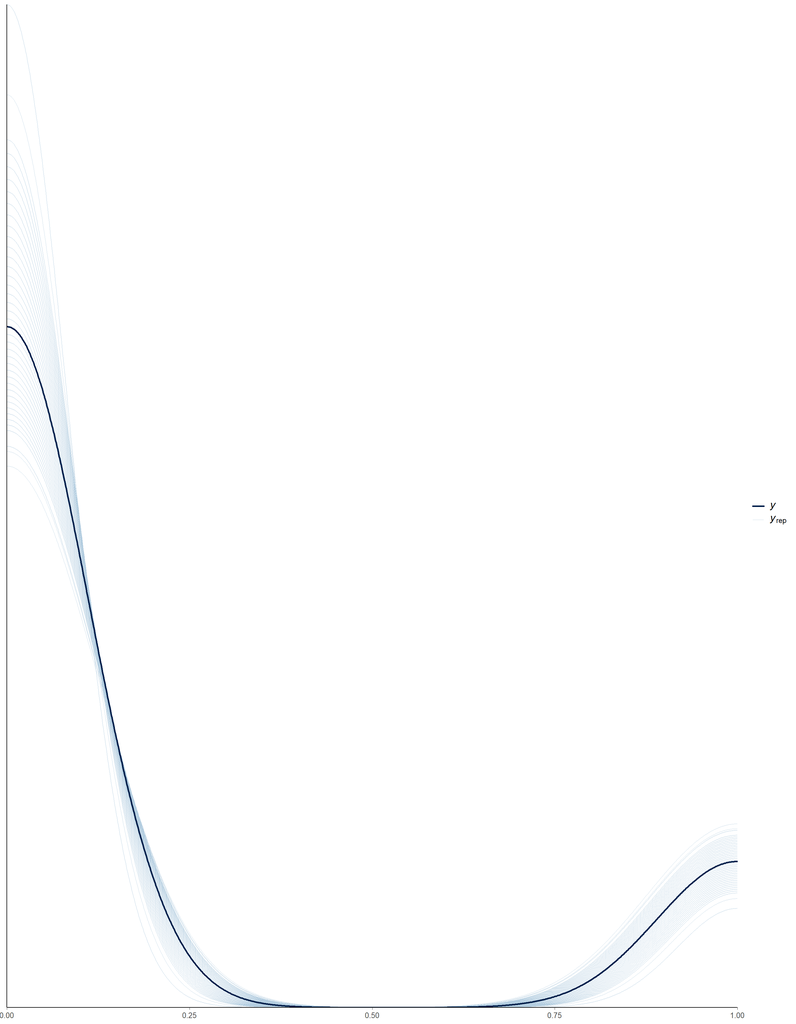

```r
ref_obj_hs<- model_imp_hs

prj_ref <- project(
  ref_obj_hs,
  verbose = F,
  predictor_terms = xvar
  )

prj_predict <- proj_predict(prj_ref)

# Using the 'bayesplot' package:
ppc_imp <- ppc_dens_overlay(y = training_set_imp$stbbi.pos, yrep = prj_predict)

ppc_imp
```

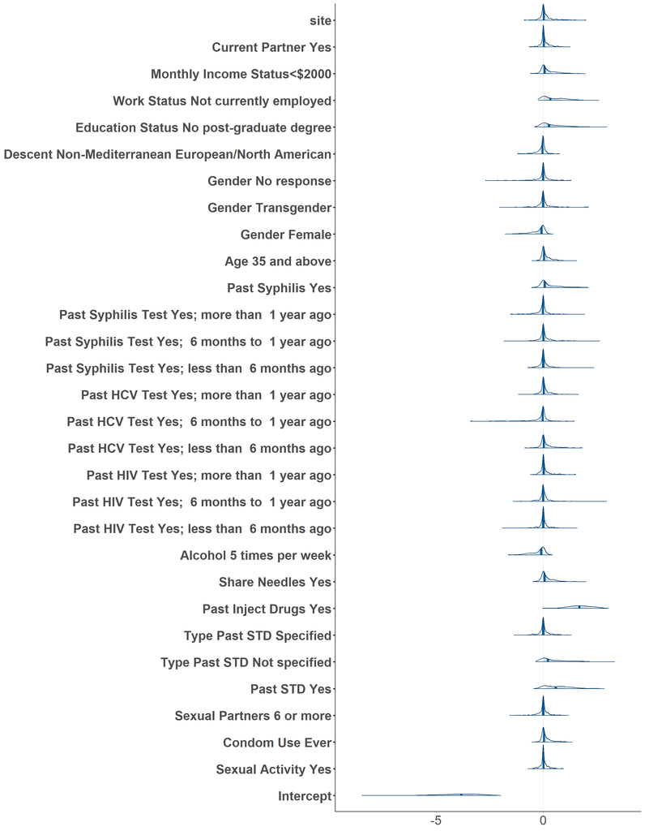

```r
# turn into matrix
prj_mat <- as.matrix(prj_ref)

# extract and clean the variable names

col <- colnames(prj_mat)
#clean colnames
new_col<- str_replace_all(col, "(b_|\\d+-)| CAD", "") %>%
  str_replace_all("(?<!\\b(?:HCV|HIV|STD|CAD))(?<=\\w)(?=[A-Z])|(?<=\\D)(?=\\d)", " ") %>%
  str_replace_all(" 2; 000", "2000") %>%
  str_replace_all("H I V", "HIV") %>%
  str_replace_all("H C V", "HCV") %>%
  str_replace_all("S T D", "STD")

# to see the posterior distribution of each beta coefficient
mcmc_imp <- mcmc_areas(prj_mat)+
  scale_y_discrete(label= new_col)+ # add new column names
  xaxis_text(size= 20)+
  yaxis_text(size = 20)

mcmc_imp
```

### Variable selection

#### Fast horseshoe prior

```r
model_fast_imp_hs <- cv_varsel(
  model_imp_hs,
  validate_search = F,
  method = "L1",
  verbose = FALSE, # remove the text
)

model_fast_imp_hs
```

```
Family: binomial
Link function: logit

Formula: stbbi.pos ~ SexualActivity + CondomUse + SexualPartners + PastSTD +
    TypePastSTD + PastInjectDrugs + ShareNeedles + Alcohol +
    PastHIVTest + PastHCVTest + PastSyphilisTest + PastSyphilis +
    Age + Gender + Descent + EducationStatus + WorkStatus + MonthlyIncomeStatus +
    CurrentPartner + site
Observations: 300
Projection method: traditional
CV method: PSIS-LOO CV with search not included (i.e., a full-data search only)
Search method: L1
Maximum submodel size for the search: 19
Number of projected draws in the search: 1 (from clustered projection)
Number of projected draws in the performance evaluation: 400
Argument `refit_prj`: TRUE

Submodel performance evaluation summary with `deltas = FALSE` and `cumulate = FALSE`:
 size    ranking_fulldata cv_proportions_diag elpd elpd.se elpd.diff
    0         (Intercept)                  NA -141    10.3    -26.44
    1     PastInjectDrugs                  NA -116     9.9     -1.81
    2         TypePastSTD                  NA -113    10.0      0.87
    3        ShareNeedles                  NA -114    10.0      0.66
    4             PastSTD                  NA -114    10.0      0.64
    5          WorkStatus                  NA -113     9.8      1.55
    6     EducationStatus                  NA -112     9.7      1.95
    7             Alcohol                  NA -112     9.6      2.04
    8        PastSyphilis                  NA -112     9.5      2.29
    9 MonthlyIncomeStatus                  NA -112     9.5      1.97
   10                 Age                  NA -112     9.6      1.81
   11              Gender                  NA -113     9.6      1.74
   12         PastHCVTest                  NA -113     9.7      1.08
   13    PastSyphilisTest                  NA -113     9.7      0.94
   14           CondomUse                  NA -113     9.8      0.85
   15             Descent                  NA -114     9.8      0.75
   16         PastHIVTest                  NA -114     9.8      0.54
   17      CurrentPartner                  NA -114     9.8      0.49
   18                site                  NA -114     9.8      0.37
   19      SexualActivity                  NA -114     9.8      0.20
 elpd.diff.se
```

[output cut: 9 more lines]

```
         0.99
         0.95
         0.69
         0.50
         0.46
         0.35
         0.33
         0.29
         0.26
         0.24
         0.23

Reference model performance evaluation summary with `deltas = FALSE`:
   elpd elpd.se
 -114.3     9.8
```

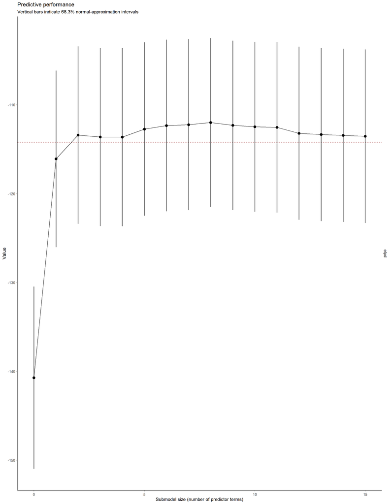

Submodels accuracy using rapid variable selection. The Y-axis represents estimated log predictive density (elpd) which is a performance statistic. The dashed red line represents the reference model performance

```r
plot(model_fast_imp_hs, stats = "elpd", ranking_nterms_max = NA)
```

#### 5-fold cross validation

we do not run the 5-fold cross validation but we will use the code for the sensitivity analysis

```r
# cv_fits_imp <- run_cvfun(
#   model_imp_hs  # 5k is default
# )
#
# # Final cv_varsel() run:
# model_imp_nk <- cv_varsel(
#   model_imp_hs,
#   cv_method = "kfold",
#   cv_fits = cv_fits_imp,
#   method = "L1",
#   nterms_max = 15,
#   verbose = F
# )
#
# model_imp_nk
#
# plot_k5 <- plot(model_imp_nk, stats = "elpd", deltas = TRUE)
# plot_k5
```

Used this method because LOO package is not supported within projpred

```r
cv_fits <- run_cvfun(
  model_imp_hs,
  K = nrow(training_set_imp))

model_imp_nk <- cv_varsel(
  model_imp_hs,
  cv_method = "kfold",
  cv_fits = cv_fits,
  nterms_max = 15, # to be safe
  method = "forward",
  verbose = F
)

model_imp_nk
```

[output not shown]

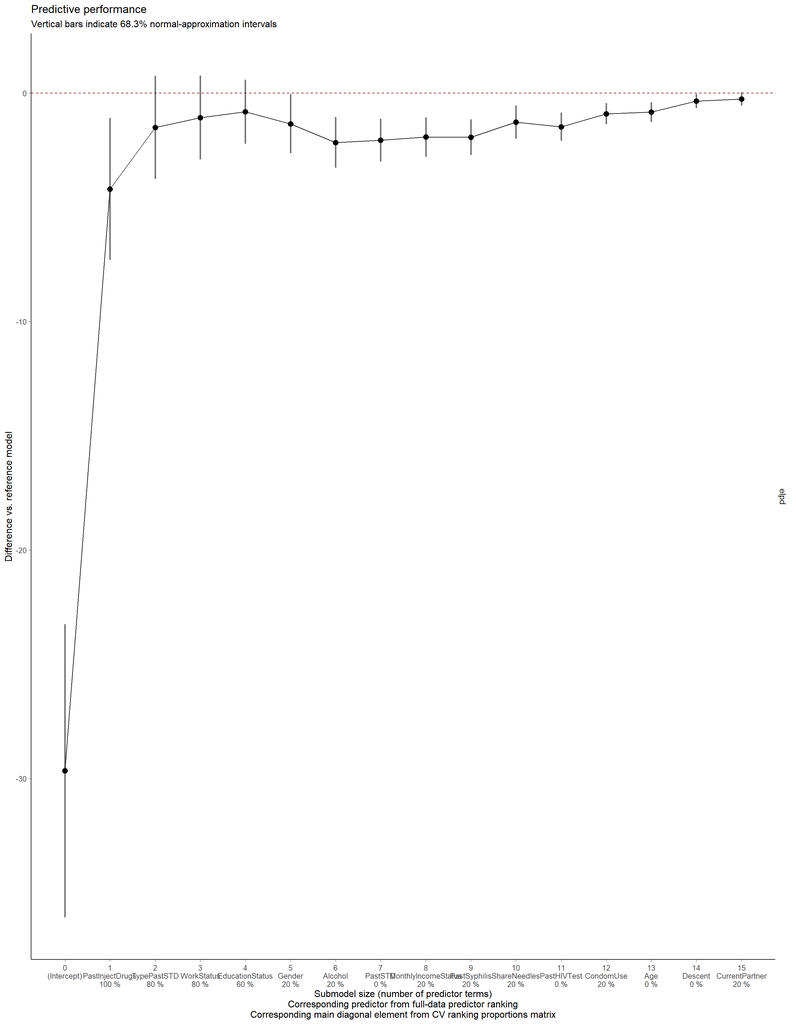

Submodels accuracy using rapid variable selection. Y axis values represent the DIFFERENCE in performance with the reference model. The percentage below each submodel represents the cross-validation ranking of predictors

```r
performance_imp <- plot(model_imp_nk, stats = "elpd", delta = T)
performance_imp
```

### Cross-validation results

```r
ranking_imp <- ranking(model_imp_nk)
```

The predictors are ranked in the following order: PastInjectDrugs, TypePastSTD, WorkStatus, EducationStatus, Gender, Alcohol, PastSTD, MonthlyIncomeStatus, PastSyphilis, ShareNeedles, PastHIVTest, CondomUse, Age, Descent, CurrentPartner

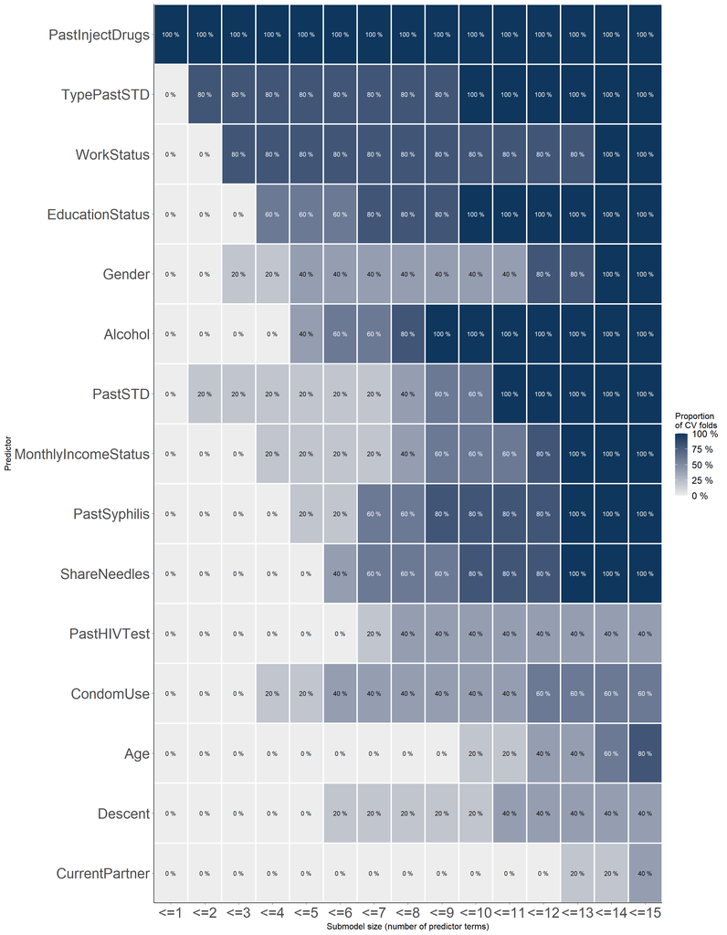

The cumulative agreement of the ranking in each cross-validation fold

```r
cumul_ranking_imp <- plot(cv_proportions(ranking_imp, cumulate = T))+
  xaxis_text(size= 20)+
  yaxis_text(size = 20)
cumul_ranking_imp
```

There is a lot of variability in predictor ranking between folds.

### Select model

```r
sugg.size <- suggest_size(model_imp_nk, stat = "elpd")

size <- 9


predictors_final_imp <- head(ranking_imp[["fulldata"]], size)
```

The suggested size for the model is 2 but we will use with the predictors in the following order PastInjectDrugs, TypePastSTD, WorkStatus, EducationStatus, Gender, Alcohol, PastSTD, MonthlyIncomeStatus, PastSyphilis

### Prediction performance

#### Training data

Sensitivity and specificity of our selected model

```r
# use the submodel function
sub_train<- submodels_train(model_imp_hs, predictor_ranking = predictors_final_imp, new_data = training_set_imp)
# measure sensitivity, specificity and AUC using cindy's formula for all models
sub_train
```

```
[[1]]
 Family: bernoulli
  Links: mu = logit
Formula: stbbi.pos ~ PastInjectDrugs
   Data: training_set_imp (Number of observations: 300)
  Draws: 4 chains, each with iter = 2000; warmup = 1000; thin = 1;
         total post-warmup draws = 4000

Population-Level Effects:
                     Estimate Est.Error l-95% CI u-95% CI Rhat Bulk_ESS
Intercept               -2.73      0.31    -3.36    -2.16 1.00     1814
PastInjectDrugs1MYes     2.25      0.37     1.52     2.98 1.00     2559
                     Tail_ESS
Intercept                1934
PastInjectDrugs1MYes     2874

Draws were sampled using sampling(NUTS). For each parameter, Bulk_ESS
and Tail_ESS are effective sample size measures, and Rhat is the potential
scale reduction factor on split chains (at convergence, Rhat = 1).

[[2]]
 Family: bernoulli
  Links: mu = logit
Formula: stbbi.pos ~ PastInjectDrugs + TypePastSTD
   Data: training_set_imp (Number of observations: 300)
  Draws: 4 chains, each with iter = 2000; warmup = 1000; thin = 1;
         total post-warmup draws = 4000

Population-Level Effects:
                        Estimate Est.Error l-95% CI u-95% CI Rhat Bulk_ESS
Intercept                  -2.95      0.36    -3.69    -2.30 1.00     2312
PastInjectDrugs1MYes        2.15      0.37     1.45     2.89 1.00     3272
TypePastSTDNotspecified     1.38      0.73    -0.00     2.73 1.00     1542
TypePastSTDSpecified        0.41      0.38    -0.13     1.19 1.00     1632
                        Tail_ESS
Intercept                   2920
PastInjectDrugs1MYes        3331
TypePastSTDNotspecified      713
TypePastSTDSpecified        2350

```

[output cut: 308 more lines]

```
PastSyphilis1MYes                                  1.64 1.00     1981     3384
Age35andabove                                      0.74 1.00     3231     3663
Gender2MFemale                                     0.16 1.00     1753     3387
Gender3MTransgender                                1.04 1.00     4144     3247
Gender5MNoresponse                                 0.83 1.00     4480     2987
DescentNonMMediterraneanEuropeanDNorthAmerican     0.30 1.00     3618     3608
EducationStatusNopostMgraduatedegree               1.89 1.00     1612     3145
WorkStatusNotcurrentlyemployed                     1.75 1.00     1422     2736
MonthlyIncomeStatus1M<$2;000CAD                    1.14 1.00     2560     3387
CurrentPartner1MYes                                0.65 1.00     3535     3508
site                                               1.02 1.00     2411     3120

Draws were sampled using sampling(NUTS). For each parameter, Bulk_ESS
and Tail_ESS are effective sample size measures, and Rhat is the potential
scale reduction factor on split chains (at convergence, Rhat = 1).
```

```r
colnames <- c(paste0("model",1:length(predictors_final_imp)), "ref")

submodels.sens<- mult.sens(training_set_imp$stbbi.pos, sub_train) # 2000 iter default
submodels.sens
```

```
   rowname       Q50      Q5.5     Q94.5      Q2.5     Q97.5
1   model1 0.8542510 0.8056680 0.8947368 0.7935223 0.9028340
2   model2 0.8582996 0.8178138 0.8987854 0.8056680 0.9109312
3   model3 0.8623482 0.8178138 0.8987854 0.8056680 0.9109312
4   model4 0.8623482 0.8178138 0.8987854 0.8056680 0.9068826
5   model5 0.8663968 0.8178138 0.9028340 0.8097166 0.9109312
6   model6 0.8663968 0.8218623 0.9068826 0.8137652 0.9149798
7   model7 0.8663968 0.8259109 0.9030567 0.8137652 0.9149798
8   model8 0.8663968 0.8256883 0.9028340 0.8137652 0.9109312
9   model9 0.8663968 0.8218623 0.9028340 0.8097166 0.9109312
10     ref 0.8623482 0.8218623 0.9028340 0.8096154 0.9109312
```

```r
submodels.spec<- mult.spec(training_set_imp$stbbi.pos, sub_train) # 2000 iter default
submodels.spec
```

```
   rowname       Q50      Q5.5     Q94.5      Q2.5     Q97.5
1   model1 0.3207547 0.2075472 0.4339623 0.1886792 0.4528302
2   model2 0.3584906 0.2452830 0.4528302 0.2259434 0.4905660
3   model3 0.3584906 0.2452830 0.4716981 0.2264151 0.5094340
4   model4 0.3773585 0.2641509 0.4716981 0.2264151 0.5094340
5   model5 0.3773585 0.2641509 0.4905660 0.2264151 0.5094340
6   model6 0.3773585 0.2641509 0.4905660 0.2452830 0.5094340
7   model7 0.3773585 0.2641509 0.4905660 0.2452830 0.5283019
8   model8 0.3773585 0.2641509 0.4905660 0.2452830 0.5283019
9   model9 0.3773585 0.2641509 0.4905660 0.2452830 0.5283019
10     ref 0.3584906 0.2452830 0.4905660 0.2264151 0.5094340
```

```r
submodels.auc<- mult.auc(training_set_imp$stbbi.pos, sub_train)
submodels.auc
```

```
   rowname       Q50      Q5.5     Q94.5      Q2.5     Q97.5
1   model1 0.7646475 0.7646475 0.7646475 0.7646475 0.7646475
2   model2 0.8125430 0.7576961 0.8125430 0.7553281 0.8125430
3   model3 0.8290047 0.7936284 0.8307616 0.7750535 0.8319074
4   model4 0.8361852 0.8071534 0.8435948 0.7887270 0.8437533
5   model5 0.8422962 0.8165831 0.8500497 0.8003170 0.8511955
6   model6 0.8429073 0.8186922 0.8548239 0.8084543 0.8567355
7   model7 0.8471087 0.8249561 0.8580364 0.8139542 0.8600202
8   model8 0.8450844 0.8242304 0.8562413 0.8161294 0.8580723
9   model9 0.8486365 0.8273115 0.8611684 0.8191429 0.8627683
10     ref 0.8363379 0.7982117 0.8585712 0.7833130 0.8623100
```

The specificity is much lower than the sensitivity. We will also add the reference model values

Combine all values and save to plot later

```r
submodels_perf <- bind_rows(submodels.sens, submodels.spec, submodels.auc) %>%
  rename(model = rowname) %>%
  mutate(performance = rep(c("sensitivity", "specificity", "auc"), each=length(colnames)),
         data = "training")
```

#### Testing data

We fit our submodels with testing data and extract the sensitivity, specificity and AUC

```r
sub_test<- submodels_test(sub_train, new_data = testing_set_imp)

# measure sensitivity, specificity and AUC using cindy's formula for all models
sub_test
```

```
[[1]]
 Family: bernoulli
  Links: mu = logit
Formula: stbbi.pos ~ PastInjectDrugs
   Data: training_set_imp (Number of observations: 300)
  Draws: 4 chains, each with iter = 2000; warmup = 1000; thin = 1;
         total post-warmup draws = 4000

Population-Level Effects:
                     Estimate Est.Error l-95% CI u-95% CI Rhat Bulk_ESS
Intercept               -2.73      0.31    -3.36    -2.16 1.00     1814
PastInjectDrugs1MYes     2.25      0.37     1.52     2.98 1.00     2559
                     Tail_ESS
Intercept                1934
PastInjectDrugs1MYes     2874

Draws were sampled using sampling(NUTS). For each parameter, Bulk_ESS
and Tail_ESS are effective sample size measures, and Rhat is the potential
scale reduction factor on split chains (at convergence, Rhat = 1).

[[2]]
 Family: bernoulli
  Links: mu = logit
Formula: stbbi.pos ~ PastInjectDrugs + TypePastSTD
   Data: training_set_imp (Number of observations: 300)
  Draws: 4 chains, each with iter = 2000; warmup = 1000; thin = 1;
         total post-warmup draws = 4000

Population-Level Effects:
                        Estimate Est.Error l-95% CI u-95% CI Rhat Bulk_ESS
Intercept                  -2.95      0.36    -3.69    -2.30 1.00     2312
PastInjectDrugs1MYes        2.15      0.37     1.45     2.89 1.00     3272
TypePastSTDNotspecified     1.38      0.73    -0.00     2.73 1.00     1542
TypePastSTDSpecified        0.41      0.38    -0.13     1.19 1.00     1632
                        Tail_ESS
Intercept                   2920
PastInjectDrugs1MYes        3331
TypePastSTDNotspecified      713
TypePastSTDSpecified        2350

```

[output cut: 308 more lines]

```
PastSyphilis1MYes                                  1.64 1.00     1981     3384
Age35andabove                                      0.74 1.00     3231     3663
Gender2MFemale                                     0.16 1.00     1753     3387
Gender3MTransgender                                1.04 1.00     4144     3247
Gender5MNoresponse                                 0.83 1.00     4480     2987
DescentNonMMediterraneanEuropeanDNorthAmerican     0.30 1.00     3618     3608
EducationStatusNopostMgraduatedegree               1.89 1.00     1612     3145
WorkStatusNotcurrentlyemployed                     1.75 1.00     1422     2736
MonthlyIncomeStatus1M<$2;000CAD                    1.14 1.00     2560     3387
CurrentPartner1MYes                                0.65 1.00     3535     3508
site                                               1.02 1.00     2411     3120

Draws were sampled using sampling(NUTS). For each parameter, Bulk_ESS
and Tail_ESS are effective sample size measures, and Rhat is the potential
scale reduction factor on split chains (at convergence, Rhat = 1).
```

```r
submodels.sens.t<- mult.sens(testing_set_imp$stbbi.pos, sub_test) # 2000 iter default
submodels.sens.t
```

```
   rowname    Q50   Q5.5  Q94.5      Q2.5 Q97.5
1   model1 0.8500 0.7875 0.9125 0.7625000 0.925
2   model2 0.8500 0.7875 0.9125 0.7625000 0.925
3   model3 0.8500 0.7875 0.9125 0.7625000 0.925
4   model4 0.8500 0.7875 0.9125 0.7750000 0.925
5   model5 0.8500 0.7875 0.9125 0.7625000 0.925
6   model6 0.8500 0.7875 0.9125 0.7746875 0.925
7   model7 0.8625 0.7875 0.9125 0.7750000 0.925
8   model8 0.8500 0.7875 0.9125 0.7750000 0.925
9   model9 0.8500 0.7875 0.9125 0.7750000 0.925
10     ref 0.8500 0.7875 0.9125 0.7750000 0.925
```

```r
submodels.spec.t<- mult.spec(testing_set_imp$stbbi.pos, sub_test) # 2000 iter default
submodels.spec.t
```

```
   rowname  Q50 Q5.5 Q94.5 Q2.5 Q97.5
1   model1 0.30 0.10  0.45 0.10  0.50
2   model2 0.30 0.15  0.50 0.15  0.50
3   model3 0.30 0.15  0.45 0.10  0.50
4   model4 0.30 0.15  0.45 0.10  0.50
5   model5 0.35 0.15  0.50 0.15  0.50
6   model6 0.35 0.15  0.50 0.15  0.55
7   model7 0.35 0.15  0.50 0.15  0.50
8   model8 0.30 0.15  0.50 0.15  0.50
9   model9 0.35 0.20  0.50 0.15  0.55
10     ref 0.30 0.15  0.50 0.15  0.55
```

```r
submodels.auc.t<- mult.auc(testing_set_imp$stbbi.pos, sub_test)
submodels.auc.t
```

```
   rowname       Q50      Q5.5     Q94.5      Q2.5     Q97.5
1   model1 0.7187500 0.7187500 0.7187500 0.7187500 0.7187500
2   model2 0.7912500 0.6650000 0.7918750 0.6525000 0.7918750
3   model3 0.7740625 0.7240625 0.8028125 0.6809375 0.8053125
4   model4 0.7437500 0.7062500 0.7906250 0.6950000 0.7981250
5   model5 0.7506250 0.7000000 0.7956250 0.6831250 0.8037500
6   model6 0.7625000 0.7100000 0.8037844 0.6956250 0.8118750
7   model7 0.7706250 0.7155906 0.8106250 0.7025000 0.8162812
8   model8 0.7671875 0.7181250 0.8081250 0.7056250 0.8131250
9   model9 0.7803125 0.7246875 0.8190625 0.7115625 0.8265625
10     ref 0.7743750 0.7031250 0.8256594 0.6837187 0.8356406
```

Specificity remains very similar regardless of model size

```r
# combine
combined <- bind_rows(submodels.sens.t, submodels.spec.t, submodels.auc.t) %>%
  rename(model = rowname) %>%
  mutate(performance = rep(c("sensitivity", "specificity", "auc"), each=length(colnames)),
         data = "testing")


submodels_perf <- submodels_perf %>% bind_rows(combined)
```

## Best performing model

select and save the best performing model

```r
n_final<- which.max(submodels.auc.t$Q50)
n_final
```

```
[1] 2
```

```r
# select model 2 and transform into array
array <- as.array(sub_test[[n_final]])

parameters<- dimnames(array)$variable[grep("^b_", dimnames(array)$variable)] # extract the names of parameters to plot

parameters
```

```
[1] "b_Intercept"               "b_PastInjectDrugs1MYes"
[3] "b_TypePastSTDNotspecified" "b_TypePastSTDSpecified"
```

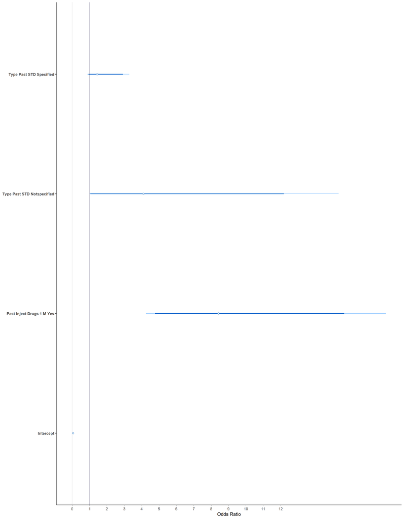

```r
# clean parameters
param_clean <- parameters %>%
  str_replace_all("(b_|\\d+-)| CAD", "") %>%
  str_replace_all("(?<!\\b(?:HCV|HIV|STD|CAD))(?<=\\w)(?=[A-Z])|(?<=\\D)(?=\\d)", " ") %>%
  str_replace_all(" 2; 000", "2000") %>%
  str_replace_all("H I V", "HIV") %>%
  str_replace_all("H C V", "HCV") %>%
  str_replace_all("S T D", "STD")

color_scheme_set("brightblue")

OR.plot <-
  mcmc_intervals(array %>% exp(), # turn logodds into odds
                 pars = parameters, # select which parameters to show
                 prob = 0.89, # set 89% CrI
                 prob_outer = 0.95, # set 95% CrI
                 outer_size = 0.5, # set sizes
                 inner_size = 1,
                 point_size = 2)+
scale_x_continuous(breaks = seq(0,12,1)) +
scale_y_discrete(labels = param_clean)+ # set limits
  geom_vline(xintercept = 1, color = "#36325c", alpha = 0.5)+
  # geom_vline(xintercept = 0, color = "white")+
  labs(x = "Odds Ratio")

OR.plot
```

Extract the OR of all predictors into a dataframe

```r
summary(sub_test[[n_final]], prob = 0.89)
```

```
 Family: bernoulli
  Links: mu = logit
Formula: stbbi.pos ~ PastInjectDrugs + TypePastSTD
   Data: training_set_imp (Number of observations: 300)
  Draws: 4 chains, each with iter = 2000; warmup = 1000; thin = 1;
         total post-warmup draws = 4000

Population-Level Effects:
                        Estimate Est.Error l-89% CI u-89% CI Rhat Bulk_ESS
Intercept                  -2.95      0.36    -3.55    -2.40 1.00     2312
PastInjectDrugs1MYes        2.15      0.37     1.56     2.75 1.00     3272
TypePastSTDNotspecified     1.38      0.73     0.05     2.50 1.00     1542
TypePastSTDSpecified        0.41      0.38    -0.06     1.07 1.00     1632
                        Tail_ESS
Intercept                   2920
PastInjectDrugs1MYes        3331
TypePastSTDNotspecified      713
TypePastSTDSpecified        2350

Draws were sampled using sampling(NUTS). For each parameter, Bulk_ESS
and Tail_ESS are effective sample size measures, and Rhat is the potential
scale reduction factor on split chains (at convergence, Rhat = 1).
```

```r
OR_final <- exp(fixef(sub_test[[n_final]], prob = c(0.055, 0.945, 0.025, 0.975))) %>% round(2) %>% as.data.frame()

OR_final
```

```
                        Estimate Est.Error Q5.5 Q94.5 Q2.5 Q97.5
Intercept                   0.05      1.44 0.03  0.09 0.03  0.10
PastInjectDrugs1MYes        8.54      1.45 4.77 15.66 4.26 18.06
TypePastSTDNotspecified     3.97      2.07 1.05 12.18 1.00 15.34
TypePastSTDSpecified        1.50      1.46 0.94  2.91 0.88  3.28
```

### Save files

Only save if there is no overfitting issue

```r
#save
if(sum(submodels.auc.t$Q50) <= sum(submodels.auc$Q50)){
write.csv(submodels_perf, "3_intermediate/projpred/submodels_performance.csv", row.names = F)
ggsave("4_outputs/OR_final_model.png", OR.plot, device = png, width = 5, height = 3)
write.csv(OR_final, file = "4_outputs/OR_final.csv")
ggsave("4_outputs/posteriors_full_model.png",mcmc_imp, device= "png", width = 16, height = 14)
ggsave("3_intermediate/projpred/ppc_density_outcome.png",
       ppc_imp, device = "png", width = 16, height = 7)
}else{
  print("Error: overfitting")
}
```